# How to use xmR() and xmR_chart()

Alex Zanidean

# Introduction

XMR control charts are useful when determining if there are significant trends in data. XMR charts have two key assumptions: one is that the measurements of value happen over time, and the other is that each measurement of time has one measurement of value.

Take careful thought about *what* you are trying to measure with XMR. Proportions work best, headcount is okay, costs over time aren’t great.

# Arguments

The arguments for `xmR()` are as follows.

- **df**: The dataframe containing the time-series data. At least 1 variable for time and one variable for measure.
- **measure**: The column containing the measure. Must be in a numeric format.
- **interval**: The interval you’d like to use to calculate the averages. Defaults to 5.
- **recalc**: Logical if you’d like it to recalculate bounds. Defaults to False for safety.

The data required for XMR charts take a specific format, with at least two columns of data - one for the time variable and another for the measurement. Like so:

| Time | Measure |
| --- | --- |
| 2000 | 57 |
| 2001 | 59 |
| 2002 | 64 |
| 2003 | 73 |
| 2004 | 55 |
| 2005 | 72 |
| 2006 | 74 |
| 2007 | 67 |
| 2008 | 66 |
| 2009 | 52 |
| 2010 | 80 |
| 2011 | 79 |
| 2012 | 92 |
| 2013 | 85 |
| 2014 | 94 |
| 2015 | 87 |
| 2016 | 93 |
| 2017 | 100 |

The function use on this set of data would be written like this if we wanted the boundries to recalculate.

```r
xmr_data <- xmR(df = example_data, measure = "Measure", recalc = T)
```

The measure column must be written within quotes.

Output data looks like this:

| Time | Measure | Central Line | Moving Range | Average Moving Range | Lower Natural Process Limit | Upper Natural Process Limit |
| --- | --- | --- | --- | --- | --- | --- |
| 2000 | 57 | 61.600 | NA | NA | NA | NA |
| 2001 | 59 | 61.600 | 2 | 8.5 | 38.990 | 84.210 |
| 2002 | 64 | 61.600 | 5 | 8.5 | 38.990 | 84.210 |
| 2003 | 73 | 61.600 | 9 | 8.5 | 38.990 | 84.210 |
| 2004 | 55 | 61.600 | 18 | 8.5 | 38.990 | 84.210 |
| 2005 | 72 | 61.600 | 17 | 8.5 | 38.990 | 84.210 |
| 2006 | 74 | 61.600 | 2 | 8.5 | 38.990 | 84.210 |
| 2007 | 67 | 61.600 | 7 | 8.5 | 38.990 | 84.210 |
| 2008 | 66 | 61.600 | 1 | 8.5 | 38.990 | 84.210 |
| 2009 | 52 | 61.600 | 14 | 8.5 | 38.990 | 84.210 |
| 2010 | 80 | 83.667 | 28 | 14.0 | 46.427 | 120.907 |
| 2011 | 79 | 83.667 | 1 | 14.0 | 46.427 | 120.907 |
| 2012 | 92 | 83.667 | 13 | 14.0 | 46.427 | 120.907 |
| 2013 | 85 | 83.667 | 7 | 14.0 | 46.427 | 120.907 |
| 2014 | 94 | 83.667 | 9 | 14.0 | 46.427 | 120.907 |
| 2015 | 87 | 83.667 | 7 | 14.0 | 46.427 | 120.907 |
| 2016 | 93 | 83.667 | 6 | 14.0 | 46.427 | 120.907 |
| 2017 | 100 | 83.667 | 7 | 14.0 | 46.427 | 120.907 |

# Charts

That data calculation is handy, but what about visualiztion?

There is a function called `xmR_chart()` which takes that output, and generates a ggplot graphic so the user can identify trends in the data.

The arguments for `xmR_chart()` are as follows.

- **dataframe**: Output from xmR()
- **time**: The column containing the time variable for the x-axis.
- **measure**: The column containing the measure for the y-axis.
- **facetvar**: Split the chart by a facet variable. Explained in the next section.

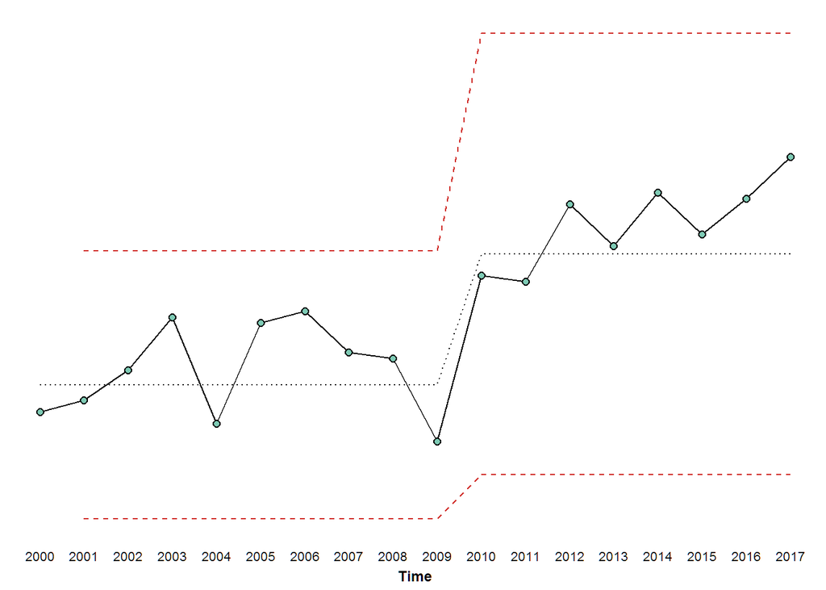

```r
xmR_chart(dataframe = xmr_data, time = "Time", measure = "Measure")
```

# Other Packages

Simple datasets like those illustrated above are common, but more common are large datasets with multiple factors. Consider the following data. How would the `xmR()` function benefit the user in this case?

| Academic Year | Gender | FLE |
| --- | --- | --- |
| 2004-05 | Female | 1542.482 |
| 2004-05 | Male | 784.034 |
| 2005-06 | Female | 1534.586 |
| 2005-06 | Male | 748.378 |
| 2006-07 | Female | 1447.224 |
| 2006-07 | Male | 769.756 |
| 2007-08 | Female | 1431.162 |
| 2007-08 | Male | 780.894 |
| 2008-09 | Female | 1390.287 |
| 2008-09 | Male | 814.021 |
| 2009-10 | Female | 1452.921 |
| 2009-10 | Male | 915.347 |
| 2010-11 | Female | 1403.036 |
| 2010-11 | Male | 912.465 |
| 2011-12 | Female | 1351.024 |
| 2011-12 | Male | 894.775 |
| 2012-13 | Female | 1307.990 |
| 2012-13 | Male | 885.586 |
| 2013-14 | Female | 1194.263 |
| 2013-14 | Male | 928.649 |
| 2014-15 | Female | 1178.329 |
| 2014-15 | Male | 883.926 |
| 2015-16 | Female | 1178.902 |
| 2015-16 | Male | 901.099 |

The answer is by leveraging other R packages, namely the `tidyverse`.

You can install and load the tidyverse by the following.

```r
install.packages("tidyverse")
library(tidyverse)
```

# Grouping and Faceting

| Academic Year | Gender | FLE | Order | Central Line | Moving Range | Average Moving Range | Lower Natural Process Limit | Upper Natural Process Limit |
| --- | --- | --- | --- | --- | --- | --- | --- | --- |
| 2004-05 | Female | 1542.482 | 1 | 1469.148 | NA | NA | NA | NA |
| 2005-06 | Female | 1534.586 | 2 | 1469.148 | 7.896 | 38.049 | 1367.939 | 1570.358 |
| 2006-07 | Female | 1447.224 | 3 | 1469.148 | 87.362 | 38.049 | 1367.939 | 1570.358 |
| 2007-08 | Female | 1431.162 | 4 | 1469.148 | 16.062 | 38.049 | 1367.939 | 1570.358 |
| 2008-09 | Female | 1390.287 | 5 | 1469.148 | 40.875 | 38.049 | 1367.939 | 1570.358 |
| 2009-10 | Female | 1452.921 | 6 | 1469.148 | 62.634 | 38.049 | 1367.939 | 1570.358 |
| 2010-11 | Female | 1403.036 | 7 | 1354.017 | 49.885 | 51.891 | 1215.986 | 1492.047 |
| 2011-12 | Female | 1351.024 | 8 | 1354.017 | 52.012 | 51.891 | 1215.986 | 1492.047 |
| 2012-13 | Female | 1307.990 | 9 | 1354.017 | 43.034 | 51.891 | 1215.986 | 1492.047 |
| 2013-14 | Female | 1194.263 | 10 | 1183.831 | 113.727 | 43.317 | 1068.608 | 1299.055 |
| 2014-15 | Female | 1178.329 | 11 | 1183.831 | 15.934 | 43.317 | 1068.608 | 1299.055 |
| 2015-16 | Female | 1178.902 | 12 | 1183.831 | 0.573 | 43.317 | 1068.608 | 1299.055 |
| 2004-05 | Male | 784.034 | 1 | 779.417 | NA | NA | NA | NA |
| 2005-06 | Male | 748.378 | 2 | 779.417 | 35.656 | 25.325 | 712.053 | 846.780 |
| 2006-07 | Male | 769.756 | 3 | 779.417 | 21.378 | 25.325 | 712.053 | 846.780 |
| 2007-08 | Male | 780.894 | 4 | 779.417 | 11.138 | 25.325 | 712.053 | 846.780 |
| 2008-09 | Male | 814.021 | 5 | 779.417 | 33.127 | 25.325 | 712.053 | 846.780 |
| 2009-10 | Male | 915.347 | 6 | 902.043 | 101.326 | 32.772 | 814.870 | 989.216 |
| 2010-11 | Male | 912.465 | 7 | 902.043 | 2.882 | 32.772 | 814.870 | 989.216 |
| 2011-12 | Male | 894.775 | 8 | 902.043 | 17.690 | 32.772 | 814.870 | 989.216 |
| 2012-13 | Male | 885.586 | 9 | 902.043 | 9.189 | 32.772 | 814.870 | 989.216 |
| 2013-14 | Male | 928.649 | 10 | 902.043 | 43.063 | 32.772 | 814.870 | 989.216 |
| 2014-15 | Male | 883.926 | 11 | 902.043 | 44.723 | 32.772 | 814.870 | 989.216 |
| 2015-16 | Male | 901.099 | 12 | 902.043 | 17.173 | 32.772 | 814.870 | 989.216 |

And as you may be able to see, the XMR data calculated on FLE **AND** by Gender, in one function instead of having to manually split the data. Now, if we tried to plot this data we would do the following.

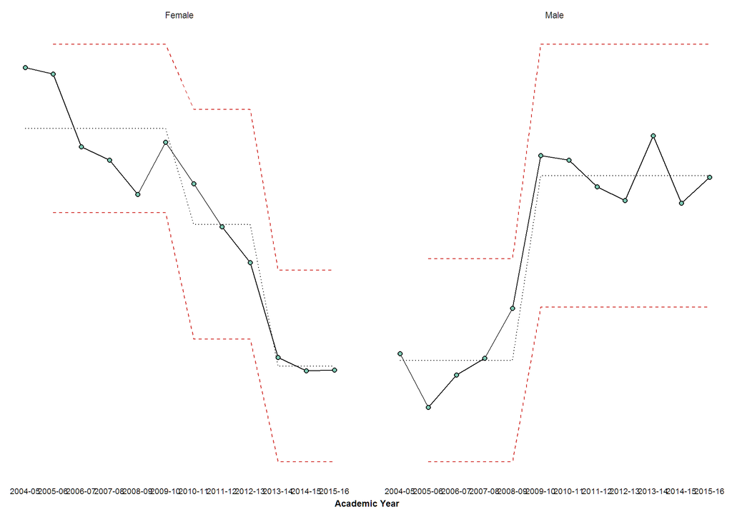

```r
xmR_chart(dataframe = lers_xmr, time = "Academic Year", measure = "FLE", facetvar = "Gender")
```